# DATA606finalexam

jim lung

05-19-2017

# Part I

## 1. A student is gathering data on the driving experiences of other college students. A description of the

data car color is presented below. Which of the variables are quantitative and discrete? car 1 = compact, 2 = standard size, 3 = mini van, 4 = SUV, and 5 = truck color red, blue, green, black, white daysDrive number of days per week the student drives gasMonth the amount of money the student spends on gas per month

4. daysDrive, gasMonth

estimates of the mean and median are most plausible?

1. mean = 3.3, median = 3.5

```r
((2.5/100) *132*1.9 + (2.5/100) *132*2.1 + (5/100) *132*2.5 + (5/100) *132*2.7 + (14/100) *132*2.9 + (5/100) *132*3.1 + (13/100) *132*3.3 + (13/100) *132*3.5 + (21/100) *132*3.7 + (20/100) *132*3.9)/132
```

```
## [1] 3.362
```

## 3. A researcher wants to determine if a new treatment is effective for reducing Ebola related fever.

What type of study should be conducted in order to establish that the treatment does indeed cause improvement in Ebola patients?

4. Both studies (a) and (b) can be conducted in order to establish that the treatment does indeed cause improvement with regards to fever in Ebola patients

## 4. A study is designed to test whether there is a relationship between natural hair color (brunette, blond,

red) and eye color (blue, green, brown). If a large ${ x }^{ 2 }$ test statistic is obtained, this suggests that:

4. eye color and natural hair color are independent

## 5. A researcher studying how monkeys remember is interested in examining the distribution of the score on

```r
#Q1 – 1.5×IQR or above Q3 + 1.5×IQR
37-1.5*(49.8-37)
```

```
## [1] 17.8
```

```r
49.8+1.5*(49.8-37)
```

```
## [1] 69
```

2. 17.8 and 69.0

## 6. The __________ are resistant to outliers, whereas the ________ are not.

4. median and interquartile range; mean and standard deviation

## a. Describe the two distributions (2 pts).

A is that the population distribution is unimodal and right skewed, the mean is to the right and concentrated on the lower end of the distribution.

B is that the sample distribution is approximated symmetric, the sample size is 30.

## b. Explain why the means of these two distributions are similar but the standard deviations are not (2

pts).

The B represent the distribution of the mean from 500 random samples of size 30 from A, because the sample size is 30 independent observations and data are not strongly skewed, so the means distribution are similar. The standard deviation is standard error for the mean estimated from the data.

```r
sd <- 3.22
n <-30
SE <- sd / sqrt(n)
SE
```

```
## [1] 0.5878889
```

Standare error, SE, is 0.5879

## c. What is the statistical principal that describes this phenomenon (2 pts)?

This is the principal of Central Limit Theorem, If a sample consists of at least 30 independent observations and the data are not strongly skewed, then the distribution of the sample mean is well approximated by a normal model.

# Part II

Consider the four datasets, each with two columns (x and y), provided below.

```r
options(digits=2)
data1 <- data.frame(x=c(10,8,13,9,11,14,6,4,12,7,5),
y=c(8.04,6.95,7.58,8.81,8.33,9.96,7.24,4.26,10.84,4.82,5.68))
data2 <- data.frame(x=c(10,8,13,9,11,14,6,4,12,7,5),
y=c(9.14,8.14,8.74,8.77,9.26,8.1,6.13,3.1,9.13,7.26,4.74))
data3 <- data.frame(x=c(10,8,13,9,11,14,6,4,12,7,5),
y=c(7.46,6.77,12.74,7.11,7.81,8.84,6.08,5.39,8.15,6.42,5.73))
data4 <- data.frame(x=c(8,8,8,8,8,8,8,19,8,8,8),
y=c(6.58,5.76,7.71,8.84,8.47,7.04,5.25,12.5,5.56,7.91,6.89))
```

For each column, calculate (to two decimal places):

## a. The mean (for x and y separately; 1 pt).

```r
#mean of data1
mean(data1$x)
```

```
## [1] 9
```

```r
mean(data1$y)
```

```
## [1] 7.5
```

```r
#mean of data2
mean(data2$x)
```

```
## [1] 9
```

```r
mean(data2$y)
```

```
## [1] 7.5
```

```r
#mean of data3
mean(data3$x)
```

```
## [1] 9
```

```r
mean(data3$y)
```

```
## [1] 7.5
```

```r
#mean of data4
mean(data4$x)
```

```
## [1] 9
```

```r
mean(data4$y)
```

```
## [1] 7.5
```

## b. The median (for x and y separately; 1 pt).

```r
#median of data1
median(data1$x)
```

```
## [1] 9
```

```r
median(data1$y)
```

```
## [1] 7.6
```

```r
#median  of data2
median(data2$x)
```

```
## [1] 9
```

```r
median(data2$y)
```

```
## [1] 8.1
```

```r
#median  of data3
median(data3$x)
```

```
## [1] 9
```

```r
median(data3$y)
```

```
## [1] 7.1
```

```r
#median  of data4
median(data4$x)
```

```
## [1] 8
```

```r
median (data4$y)
```

```
## [1] 7
```

## c. The standard deviation (for x and y separately; 1 pt).

```r
#Standard deviation  of data1
sd(data1$x)
```

```
## [1] 3.3
```

```r
sd(data1$y)
```

```
## [1] 2
```

```r
#Standard deviation  of data2
sd(data2$x)
```

```
## [1] 3.3
```

```r
sd(data2$y)
```

```
## [1] 2
```

```r
#Standard deviation  of data3
sd(data3$x)
```

```
## [1] 3.3
```

```r
sd(data3$y)
```

```
## [1] 2
```

```r
#Standard deviation  of data4
sd(data4$x)
```

```
## [1] 3.3
```

```r
sd(data4$y)
```

```
## [1] 2
```

For each x and y pair, calculate (also to two decimal places; 1 pt):

## d. The correlation (1 pt).

```r
cor(data1)
```

```
##      x    y
## x 1.00 0.82
## y 0.82 1.00
```

```r
cor(data2)
```

```
##      x    y
## x 1.00 0.82
## y 0.82 1.00
```

```r
cor(data3)
```

```
##      x    y
## x 1.00 0.82
## y 0.82 1.00
```

```r
cor(data4)
```

```
##      x    y
## x 1.00 0.82
## y 0.82 1.00
```

## e. Linear regression equation (2 pts).

```r
data1_regression <- lm(x ~ y, data = data1)
summary(data1_regression)
```

```
##
## Call:
## lm(formula = x ~ y, data = data1)
##
## Residuals:
##    Min     1Q Median     3Q    Max
## -2.652 -1.512 -0.266  1.234  3.895
##
## Coefficients:
##             Estimate Std. Error t value Pr(>|t|)
## (Intercept)   -0.998      2.434   -0.41   0.6916
## y              1.333      0.314    4.24   0.0022 **
## ---
## Signif. codes:  0 '***' 0.001 '**' 0.01 '*' 0.05 '.' 0.1 ' ' 1
##
## Residual standard error: 2 on 9 degrees of freedom
## Multiple R-squared:  0.667,  Adjusted R-squared:  0.629
## F-statistic:   18 on 1 and 9 DF,  p-value: 0.00217
```

```r
data2_regression <- lm(x ~ y, data = data2)
summary(data2_regression)
```

```
##
## Call:
## lm(formula = x ~ y, data = data2)
##
## Residuals:
##    Min     1Q Median     3Q    Max
## -1.852 -1.432 -0.344  0.847  4.202
##
## Coefficients:
##             Estimate Std. Error t value Pr(>|t|)
## (Intercept)   -0.995      2.435   -0.41   0.6925
## y              1.332      0.314    4.24   0.0022 **
## ---
## Signif. codes:  0 '***' 0.001 '**' 0.01 '*' 0.05 '.' 0.1 ' ' 1
##
## Residual standard error: 2 on 9 degrees of freedom
## Multiple R-squared:  0.666,  Adjusted R-squared:  0.629
## F-statistic:   18 on 1 and 9 DF,  p-value: 0.00218
```

```r
data3_regression <- lm(x ~ y, data = data3)
summary(data3_regression)
```

```
##
## Call:
## lm(formula = x ~ y, data = data3)
##
## Residuals:
##    Min     1Q Median     3Q    Max
## -2.987 -1.373 -0.027  1.320  3.213
##
## Coefficients:
##             Estimate Std. Error t value Pr(>|t|)
## (Intercept)   -1.000      2.436   -0.41   0.6910
## y              1.333      0.315    4.24   0.0022 **
## ---
## Signif. codes:  0 '***' 0.001 '**' 0.01 '*' 0.05 '.' 0.1 ' ' 1
##
## Residual standard error: 2 on 9 degrees of freedom
## Multiple R-squared:  0.666,  Adjusted R-squared:  0.629
## F-statistic:   18 on 1 and 9 DF,  p-value: 0.00218
```

```r
data4_regression <- lm(x ~ y, data = data4)
summary(data4_regression)
```

```
##
## Call:
## lm(formula = x ~ y, data = data4)
##
## Residuals:
##    Min     1Q Median     3Q    Max
## -2.786 -1.412 -0.185  1.455  3.333
##
## Coefficients:
##             Estimate Std. Error t value Pr(>|t|)
## (Intercept)   -1.004      2.435   -0.41   0.6898
## y              1.334      0.314    4.24   0.0022 **
## ---
## Signif. codes:  0 '***' 0.001 '**' 0.01 '*' 0.05 '.' 0.1 ' ' 1
##
## Residual standard error: 2 on 9 degrees of freedom
## Multiple R-squared:  0.667,  Adjusted R-squared:  0.63
## F-statistic:   18 on 1 and 9 DF,  p-value: 0.00216
```

## f. R-Squared (2 pts).

```r
summary(data1_regression)$r.squared
```

```
## [1] 0.67
```

```r
summary(data2_regression)$r.squared
```

```
## [1] 0.67
```

```r
summary(data3_regression)$r.squared
```

```
## [1] 0.67
```

```r
summary(data4_regression)$r.squared
```

```
## [1] 0.67
```

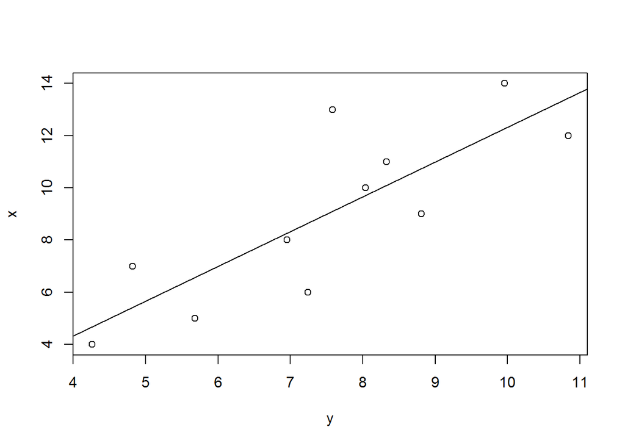

```r
plot(x ~ y, data1)
abline(data1_regression)
```

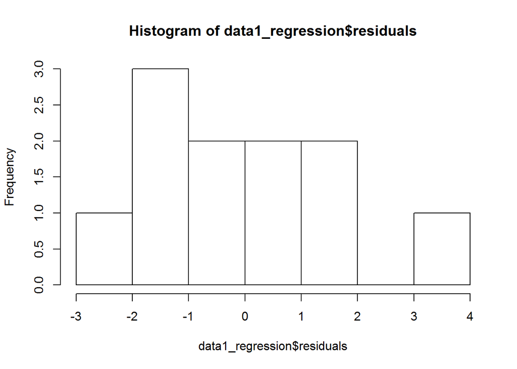

```r
hist(data1_regression$residuals)
```

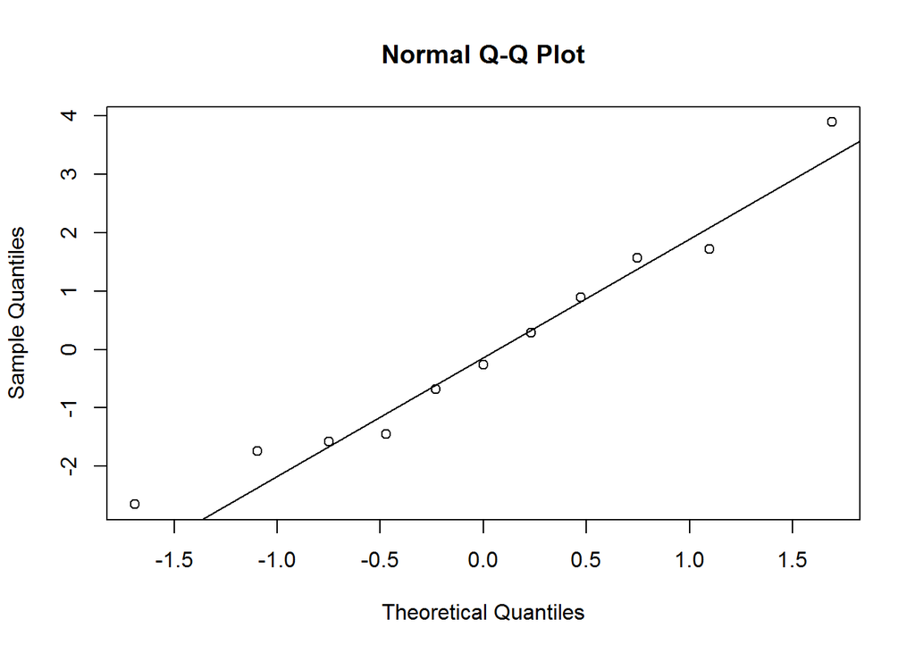

```r
qqnorm(data1_regression$residuals)
qqline(data1_regression$residuals)
```

Data1 is approriate simple linear regression, the variability of the residuals is relatively constant and nearly normal distribution.

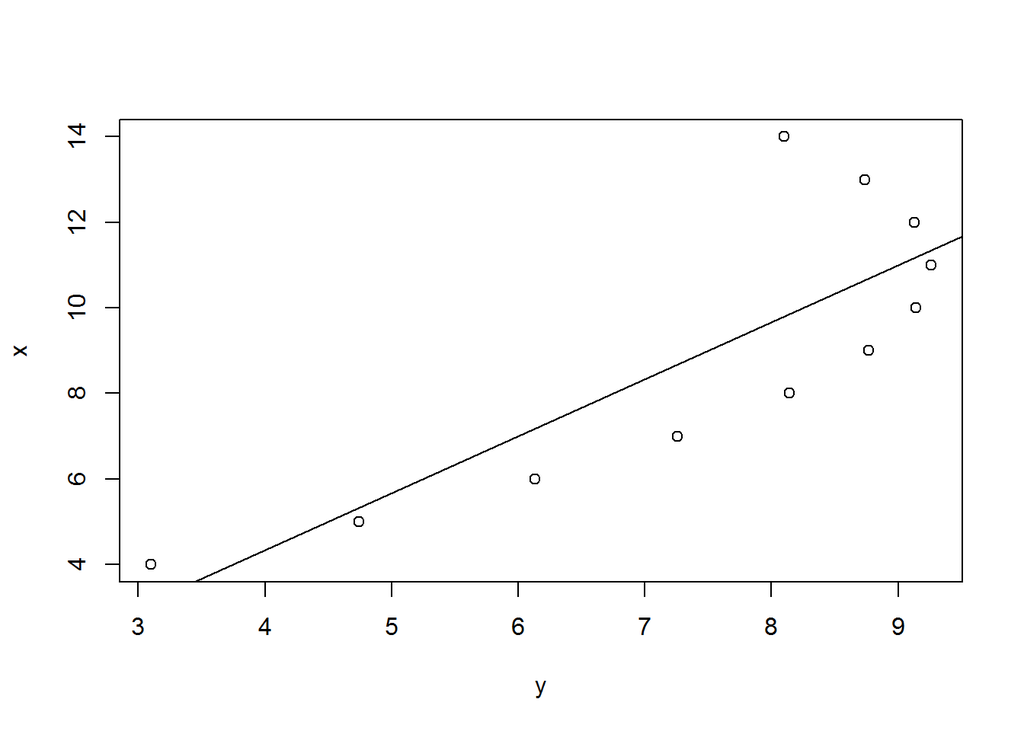

```r
plot(x ~ y, data2)
abline(data2_regression)
```

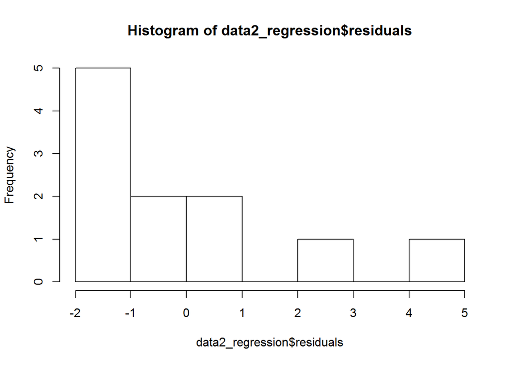

```r
hist(data2_regression$residuals)
```

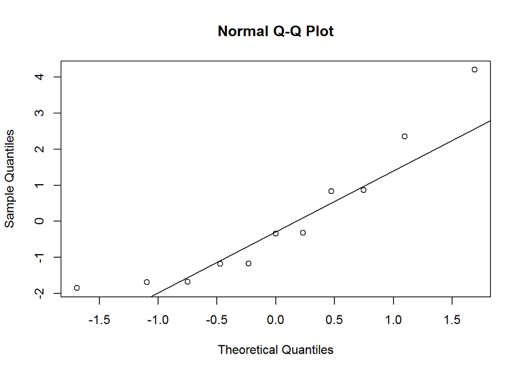

```r
qqnorm(data2_regression$residuals)
qqline(data2_regression$residuals)
```

Data2 is not a linear regression, the variability of the residuals is not constant and strong skewed distribution.

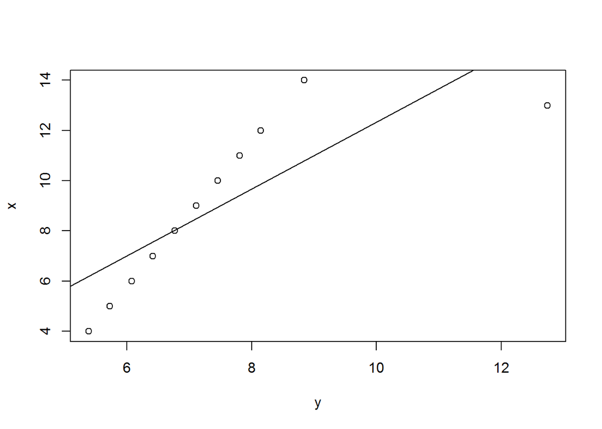

```r
plot(x ~ y, data3)
abline(data3_regression)
```

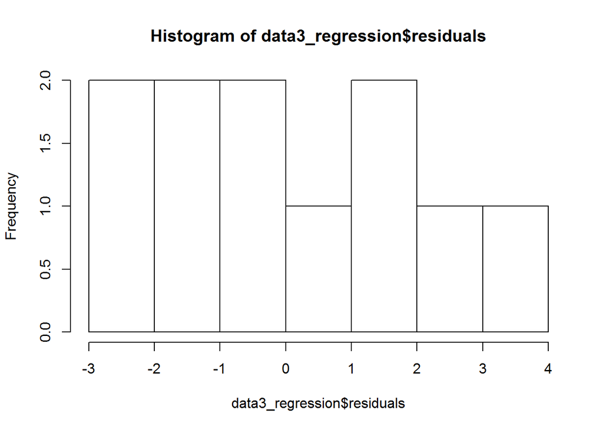

```r
hist(data3_regression$residuals)
```

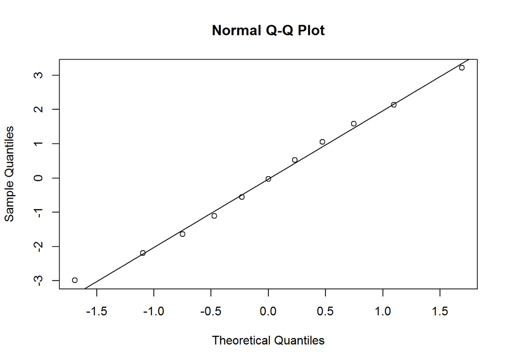

```r
qqnorm(data3_regression$residuals)
qqline(data3_regression$residuals)
```

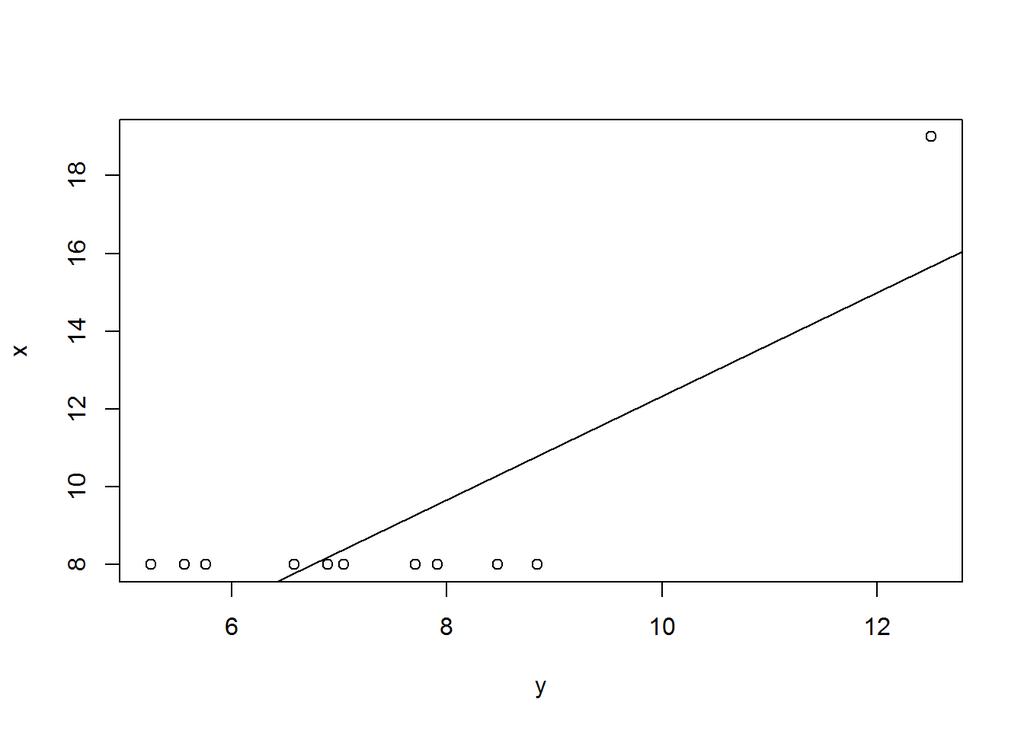

```r
plot(x ~ y, data4)
abline(data4_regression)
```

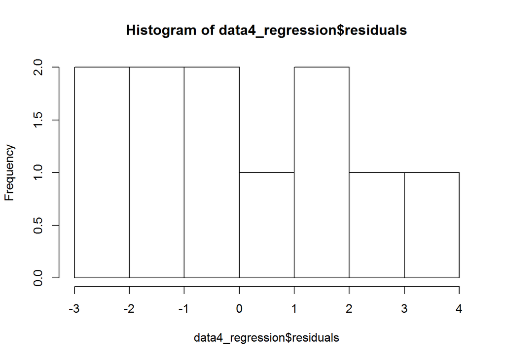

```r
hist(data4_regression$residuals)
```

Data4 is not a linear regression, the variability of the residuals is not constant.

## Explain why it is important to include appropriate visualizations when analyzing data. Include any visualization(s) you create. (2 pts)

It is really important to use graph and visuaalization for analyising data, like above data1 to data4, it has similar mean, median and standard deviation, if we just compare the data not visualization, it is not easy to identify the different of distribution and relationship. By using visualization, it can be more effective to compare the range, scope, trend of data change and relationship, such as residual distribution of data1 is nearly normal.